# re_stepwise

## Linear model fit

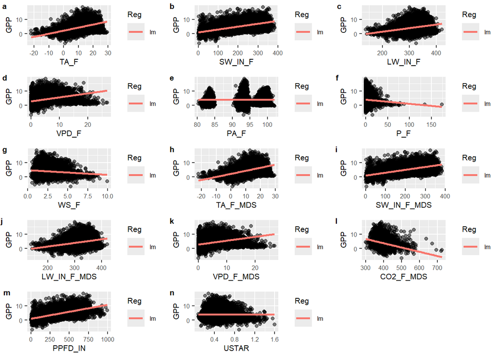

```r
# Define x variables
variables <- setdiff(names(data), "GPP_NT_VUT_REF")

# List to save plots
plots <- list()

# Plot predictors and response
for (i in seq(variables)) {
  var_name <- variables[i]
  plot <- ggplot(
    data = data,
    aes(x = .data[[var_name]], y = GPP_NT_VUT_REF)) +
    geom_point(alpha = 0.5) +
    geom_smooth(formula = y ~ x, method = "lm",
                aes(color = "lm"), se = FALSE) +
    labs(x = var_name,
         y = "GPP",
         color = "Reg") +
    theme(
      axis.title.x = element_text(size = 8),
      axis.title.y = element_text(size = 8),
      axis.text.x = element_text(size = 6),
      axis.text.y = element_text(size = 6),
      legend.text = element_text(size = 6),
      legend.title = element_text(size = 8)
    )

  plots[[i]] <- plot
}

# Combine plots
figure_1 <- cowplot::plot_grid(
  plotlist = plots,
  ncol = 3,
  labels = "auto",
  label_size = 8)

# Save figure in repository figures
ggplot2::ggsave(
  filename = here::here("figures", "Linear model fit.png"),
  plot = figure_1,
  width = 10, height = 6, dpi = 300
)

# Depict plot in html version
figure_1
```

## Quadratic model fit

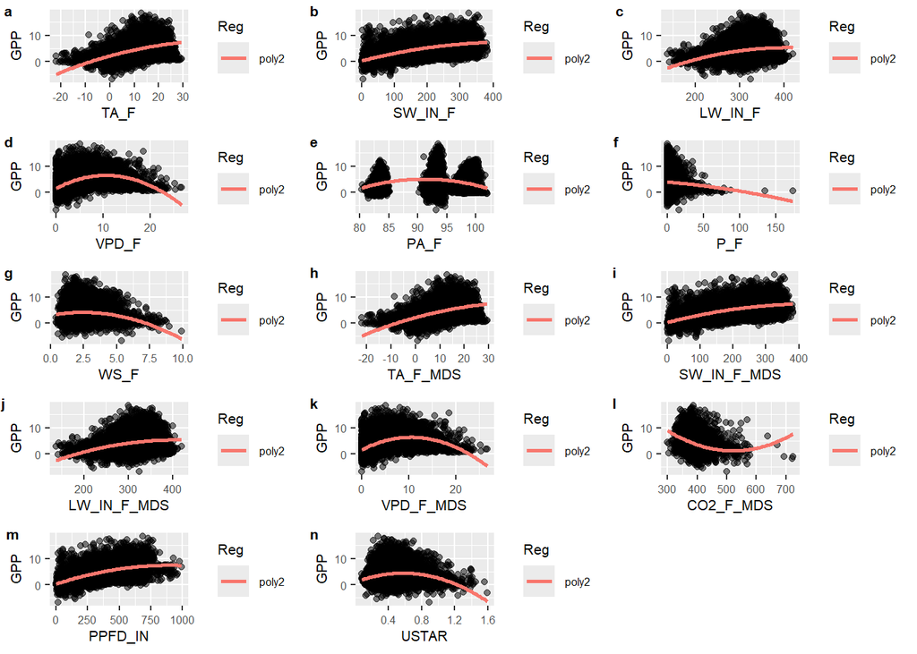

```r
# Define x variables
variables <- setdiff(names(data), "GPP_NT_VUT_REF")

# List to save plots
plots <- list()

# Plot predictors and response
for (i in seq(variables)) {
  var_name <- variables[i]
  plot <- ggplot(
    data = data,
    aes(x = .data[[var_name]], y = GPP_NT_VUT_REF)) +
    geom_point(alpha = 0.5) +
    geom_smooth(formula = y ~ poly(x, 2), method = "lm",
                aes(color = "poly2"), se = FALSE) +
    labs(x = var_name,
         y = "GPP",
         color = "Reg") +
    theme(
      axis.title.x = element_text(size = 8),
      axis.title.y = element_text(size = 8),
      axis.text.x = element_text(size = 6),
      axis.text.y = element_text(size = 6),
      legend.text = element_text(size = 6),
      legend.title = element_text(size = 8)
    )

  plots[[i]] <- plot
}

# combine plots
figure_2 <- cowplot::plot_grid(
  plotlist = plots,
  ncol = 3,
  labels = "auto",
  label_size = 8)

# Save figure in repository figures
ggplot2::ggsave(
  filename = here::here("figures", "Quadratic model fit.png"),
  plot = figure_2,
  width = 10, height = 6, dpi = 300
)

# Depict plot in html version
figure_2
```

## Model comparison R2 and AIC results

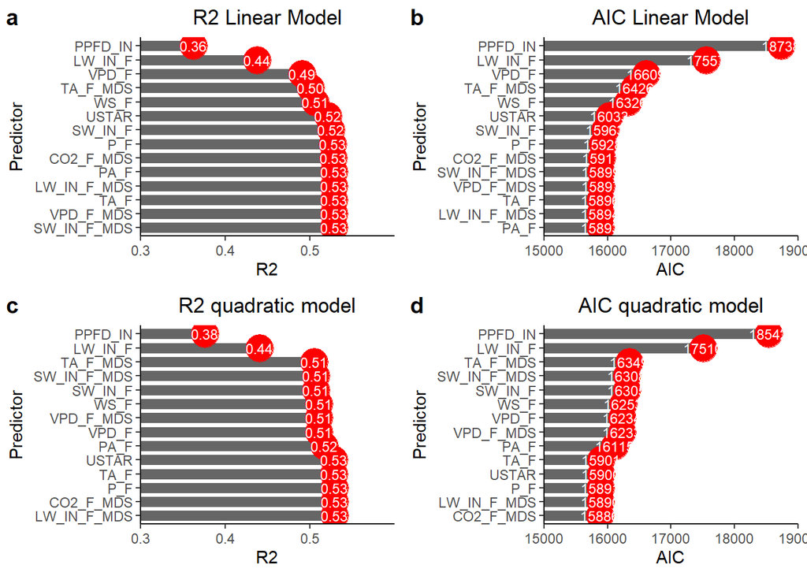

```r
# Bar chart plot linear model R2
plot_1 <- ggplot(
  data = linear_model_summary,
  aes(x = reorder(Added, -R2), y = R2)) +
  geom_segment(aes(x = reorder(Added, -R2), xend = reorder(Added, -R2), y = 0.3, yend = R2),
               size = 3, color = "grey40") +
  geom_point(aes(x = reorder(Added, -R2), y = R2), size = 8, color = "red") +
  geom_text(aes(x = reorder(Added, -R2), y = R2, label = format(R2, digits = 2)),
            size = 3, color = "white") +
  labs(title = "R2 Linear Model",
       x = "Predictor",
       y = "R2") +
  scale_y_continuous(limits = c(0.3, 0.6), expand = c(0, 0)) +
  coord_flip() +
  theme_classic() +
  theme(plot.title = element_text(hjust = 0.5))
# Bar chart plot linear model AIC
plot_2 <- ggplot(
  data = linear_model_summary,
  aes(x = reorder(Added, AIC), y = AIC)) +
  geom_segment(aes(x = reorder(Added, AIC), xend = reorder(Added, AIC), y = 15000, yend = AIC),
               size = 3, color = "grey40") +
  geom_point(aes(x = reorder(Added, AIC), y = AIC), size = 8, color = "red") +
  geom_text(aes(x = reorder(Added, AIC), y = AIC, label = format(AIC, digits = 2)),
            size = 3, color = "white") +
  labs(title = "AIC Linear Model",
       x = "Predictor",
       y = "AIC") +
  scale_y_continuous(limits = c(15000, 19000), expand = c(0, 0)) +
  coord_flip() +
  theme_classic() +
  theme(plot.title = element_text(hjust = 0.5))

# Bar chart plot quadratic model R2
plot_3 <- ggplot(
  data = quadratic_model_summary,
  aes(x = reorder(Added, -R2), y = R2)) +
  geom_segment(aes(x = reorder(Added, -R2), xend = reorder(Added, -R2), y = 0.3, yend = R2),
               size = 3, color = "grey40") +
  geom_point(aes(x = reorder(Added, -R2), y = R2), size = 8, color = "red") +
  geom_text(aes(x = reorder(Added, -R2), y = R2, label = format(R2, digits = 2)),
            size = 3, color = "white") +
  labs(title = "R2 quadratic model",
       x = "Predictor",
       y = "R2") +
  scale_y_continuous(limits = c(0.3, 0.6), expand = c(0, 0)) +
  coord_flip() +
  theme_classic() +
  theme(plot.title = element_text(hjust = 0.5))

# Bar chart plot quadratic model AIC
plot_4 <- ggplot(
  data = quadratic_model_summary,
  aes(x = reorder(Added, AIC), y = AIC)) +
  geom_segment(aes(x = reorder(Added, AIC), xend = reorder(Added, AIC), y = 15000, yend = AIC),
               size = 3, color = "grey40") +
  geom_point(aes(x = reorder(Added, AIC), y = AIC), size = 8, color = "red") +
  geom_text(aes(x = reorder(Added, AIC), y = AIC, label = format(AIC, digits = 2)),
            size = 3, color = "white") +
  labs(title = "AIC quadratic model",
       x = "Predictor",
       y = "AIC") +
  scale_y_continuous(limits = c(15000, 19000), expand = c(0, 0)) +
  coord_flip() +
  theme_classic() +
  theme(plot.title = element_text(hjust = 0.5))


# combine plots
figure_3 <- cowplot::plot_grid(
  data = plot_1, plot_2, plot_3, plot_4,
  ncol = 2,
  labels = "auto")

# Save figure in repository figures
ggplot2::ggsave(
  filename = here::here("figures", "Model comparison R2 and AIC results.png"),
  plot = figure_3,
  width = 10, height = 6, dpi = 300
)

# Depict plot in html version
figure_3
```

The viualisation of the R2 and AIC values for the linear and quadratic model regression are illustrated in the plot above. The plot emphasises again the strong model improvement when adding the variables PPFD_IN, LW_IN_F, TA_F_MDS and VPD_F with slight changes between the two models. The steps in the improvements of the R2 and AIC values suggest that the variable USTAR also improves the model.

## Interpretation

The model shows that photosynthetic photon flux density (PPFD), incoming long wave radiation (LW_IN_F) and vapor pressure deficit (VPD_F) are the core predictors of GPP. Other variables that have moderate impact on GPP are air temperature (TA_F) and friction velocity (USTAR).